# Introduction to Bayes

Univeristy of Michigan Biostatistics 699, Winter 2022

## Two designs for inference on a proportion

Adapted from Lindley and Phillips (1976). Two designs for testing \(H_0:\gamma = 0.5\)

### Design 1

In \(n=20\) independent experiments, \(R\) successes are observed. For observed value \(R=14\), one-sided \(p\)-value for testing \(H_0\):

\[ \Pr(R \geq 14|\gamma=0.5) = \sum_{x=14}^{20}\binom{20}{x}0.5^x0.5^{20-x} \] or

```r
pbinom(q = 13, size = 20, prob = 0.5, lower = F);
```

```
## [1] 0.05766
```

```r
source("invert_pvalues.R")
invert_pbinom_leftsided(q = 13, size = 20, conf_level = 0.95)$conf_int
```

```
## [1] 0.4922 1.0000
```

Confidence set of null hypotheses that we would not reject using `1-conf_level` as significance threshold given these data.

## Two designs for inference on a proportion

Adapted from Lindley and Phillips (1976). Two designs for testing \(H_0:\gamma = 0.5\)

### Design 2

\[ \Pr(R \geq 14|\gamma=0.5) = \sum_{x=14}^\infty \binom{x+5}{x}0.5^x 0.5^6 \]

```r
pnbinom(q = 13, size = 6, prob = 0.5, lower = F);
```

```
## [1] 0.03178
```

```r
invert_pnbinom_leftsided(q = 13, size = 6, conf_level = 0.95)$conf_int
```

```
## [1] 0.5242 1.0000
```

- If \(\alpha=0.05\) were significance threshold, these two experiments would yield different conclusions despite identical data
- \(p\)-values incorporate knowledge of stopping rules and sampling space (“probability of observing data as extreme or more so assuming null hypothesis is true”)
- In Design 1, sampling space of \(R\) is \(0, 1, \ldots, 20\)
- In Design 2, sampling space of \(R\) is \(0, 1, \ldots\)
- Frequentist inference is focused on frequency-based inference: if we were to repeat the data sampling mechanism multiple times, with what probability would our confidence interval cover the true parameter

## Likelihood Principle

- Up to constant, likelihood is equal up to multiplicative constant not depending on \(\gamma\): \(\gamma^{14}(1-\gamma)^6\)
- Some argue that all information from your data should be contained in the likelihood function. This is known as Likelihood Principle

## Bayesian analysis

Bayesian analysis ignores the stopping rule or sample space of a problem. Instead, needs specification of *prior* beliefs about parameter

### Bayes rule

\[\pi(\gamma | R) = \dfrac{L(R | \gamma) \pi (\gamma)}{\int_\gamma L(R | \gamma) \pi(\gamma))} = \dfrac{L(R | \gamma) \pi (\gamma)}{f(R)}\]

- \(\pi(\gamma)\) represents beliefs about parameters, prior to data collection, represented as probability distribution
- \(\pi(\gamma|R)\) is updated probability distribution after accounting for generated data that is governed by parameters

## Applied to example

- \(L(R|\gamma) \propto \gamma^{14}(1-\gamma)^6\)
- \(\pi(\gamma) \propto \gamma^{a-1}(1-\gamma)^{b-1}\)

\(\Rightarrow \pi(\gamma|R) \propto \gamma^{14}(1-\gamma)^6 \gamma^{a -1}(1-\gamma)^{b-1} = \gamma^{14+a-1}\gamma^{6+b-1}\)

\(\Rightarrow \gamma|R \sim \mathrm{Beta}(14+a, 6+b)\)

Uncertainty intervals are called *credible* intervals. Lower bounds are:

```r
# a=b=0.5
qbeta(0.05, 14.5, 6.5)
```

```
## [1] 0.518
```

```r
# a=b=4
qbeta(0.05, 18, 10)
```

```
## [1] 0.4905
```

## Non-trivial Bayesian examples

Most class examples use conjugate priors, meaning posterior distribution is same family as prior. Many interesting examples do not use conjugate priors. Define \(\beta = \log(\gamma / [1-\gamma])\). So \(\gamma =0.5 \Rightarrow \beta=0\)

- \(\pi(\beta) \propto \dfrac{1}{1 + (\beta/b)^2}\) (\(\beta\sim \mathrm{Cauchy}(0, b^2)\))
- \(\pi(\beta) \propto \exp\{-|\beta|/b\}\) (\(\beta\sim \mathrm{LaPlace}(0, b)\))

## \(\beta\sim \mathrm{Cauchy}(0, 2.5^2)\)

```r
require(rstanarm)
response_data <-
  data.frame(y = c(rep(1, 14), rep(0, 6)),
             x = rep(1, 20))

bayes_prop_cauchy <-
  stan_glm(data = response_data,
           # drop the the intercept from logistic regression
           # since x is already constant term
           formula = y ~ -1 + x,
           prior = cauchy(scale = 2.5),
           family = "binomial",
           refresh = 1000)
bayes_prop_cauchy_betas <- rstan::extract(bayes_prop_cauchy$stanfit)[["beta"]][,1]
quantile(1 / (1 + exp(-bayes_prop_cauchy_betas)), p = c(0.05, 0.5))
```

```
##     5%    50%
## 0.5123 0.6937
```

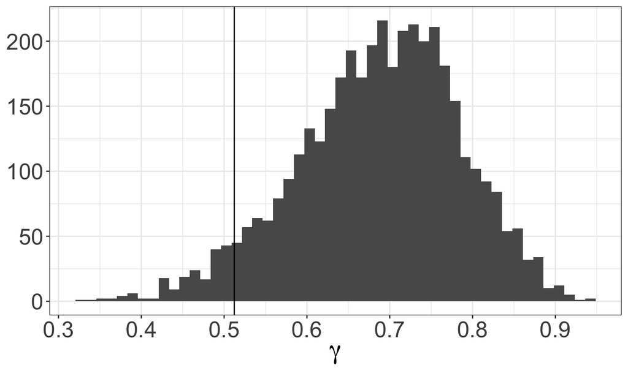

```r
ggplot(data = data.frame(gamma = 1 / (1 + exp(-bayes_prop_cauchy_betas)))) +
  geom_histogram(aes(x = gamma),
                 bins = 50) +
  geom_vline(aes(xintercept = quantile(gamma, 0.05))) +
  scale_x_continuous(name = expression(gamma),
                     breaks = seq(0, 1, by = 0.1)) +
  scale_y_continuous(name = NULL) +
  theme(text = element_text(size = 24))
```

## \(\beta\sim \mathrm{LaPlace}(0, 2.5)\)

```r
bayes_prop_laplace <-
  stan_glm(data = response_data,
           # drop the the intercept from logistic regression
           # since x is already constant term
           formula = y ~ -1 + x,
           prior = laplace(scale = 2.5),
           family = "binomial",
           refresh = 1000)
bayes_prop_laplace_betas <- rstan::extract(bayes_prop_laplace$stanfit)[["beta"]][,1]
quantile(1 / (1 + exp(-bayes_prop_laplace_betas)), p = c(0.05, 0.5))
```

```
##     5%    50%
## 0.5091 0.6866
```

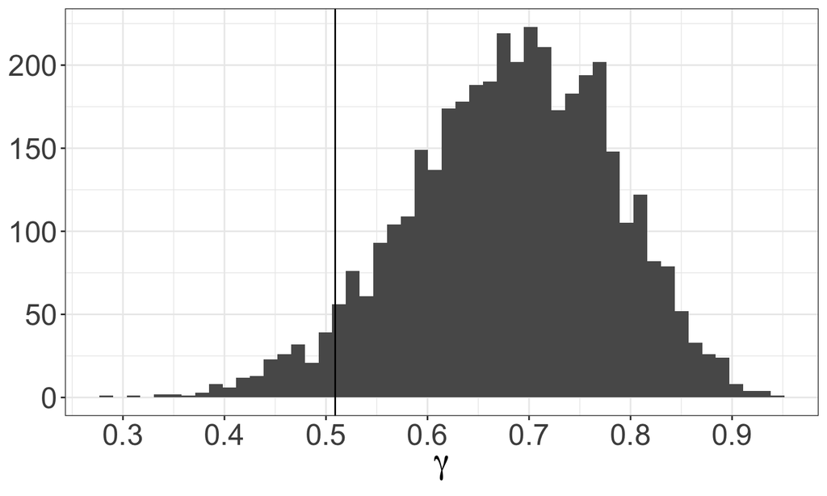

```r
ggplot(data = data.frame(gamma = 1 / (1 + exp(-bayes_prop_laplace_betas)))) +
  geom_histogram(aes(x = gamma),
                 bins = 50) +
  geom_vline(aes(xintercept = quantile(gamma, 0.05))) +
  scale_x_continuous(name = expression(gamma),
                     breaks = seq(0, 1, by = 0.1)) +
  scale_y_continuous(name = NULL) +
  theme(text = element_text(size = 24))
```

## \(\beta\sim \mathrm{LaPlace}(0, 0.05)\)

```r
bayes_prop_laplace <-
  stan_glm(data = response_data,
           # drop the the intercept from logistic regression
           # since x is already constant term
           formula = y ~ -1 + x,
           prior = laplace(scale = 0.05),
           family = "binomial",
           refresh = 1000)
bayes_prop_laplace_betas <- rstan::extract(bayes_prop_laplace$stanfit)[["beta"]][,1]
quantile(1 / (1 + exp(-bayes_prop_laplace_betas)), p = c(0.05, 0.5))
```

```
##     5%    50%
## 0.4774 0.5026
```

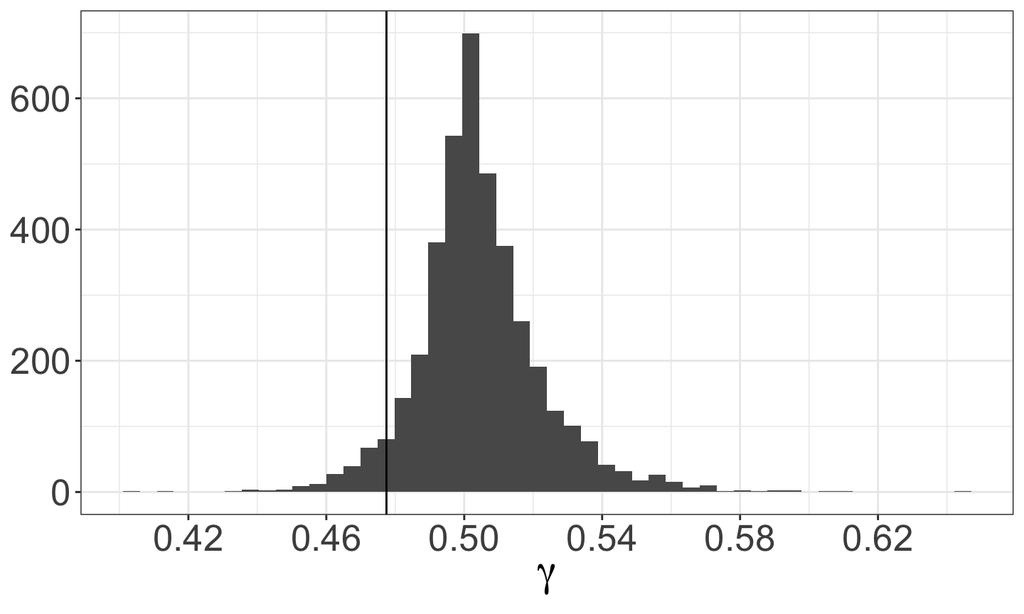

```r
ggplot(data = data.frame(gamma = 1 / (1 + exp(-bayes_prop_laplace_betas)))) +
  geom_histogram(aes(x = gamma),
                 bins = 50) +
  geom_vline(aes(xintercept = quantile(gamma, 0.05))) +
  scale_x_continuous(name = expression(gamma),
                     breaks = seq(0.02, 1, by = 0.04)) +
  scale_y_continuous(name = NULL) +
  theme(text = element_text(size = 24))
```

## How to sample from posterior

### Gibbs sampling

Conditional sampling from posterior, one parameter at time

Very similar to MICE algorithm

## How to sample from posterior

### Metropolis or Metropolis-Hastings

May not be able to characterize normalizing constant \(f(R) = \int_\gamma L(R | \gamma) \pi(\gamma))\):

\[\pi(\gamma | R) = \dfrac{L(R | \gamma) \pi (\gamma)}{\int_\gamma L(R | \gamma) \pi(\gamma))} = \dfrac{L(R | \gamma) \pi (\gamma)}{f(R)}\] But nearly always can completely characterize ratio of posterior for two values:

\[ \dfrac{\pi(\gamma_1 | R)}{\pi(\gamma_2 | R)} = \dfrac{L(R | \gamma=\gamma_1) \pi (\gamma_1)}{f(R)}\dfrac{f(R)}{L(R | \gamma=\gamma_2) \pi (\gamma_2)}=\dfrac{L(R | \gamma=\gamma_1) \pi (\gamma_1)}{L(R | \gamma=\gamma_2) \pi (\gamma_2)}\]

## Bayesian software available to R users

- WinBUGS (Gibbs Sampling when possible, MH otherwise)
- JAGS (Gibbs Sampling when possible, MH otherwise)
- STAN (Uses Hamiltonian Monte Carlo)
  - In `R`, `rstanarm` for standard models; `rstan` and `cmdstanr` for writing your own models
  - STAN is also implemented in other languages (Python, Julia, others)

## Is MLE frequentist?

- Strictly speaking, it is not frequentist for finite sample sizes.
- But frequentists still use maximum likelihood, because it is consistent, asymptotically unbiased, and controls error rates.
- Frequentists usually write likelihood as function of *parameters* conditional on observed *data*, i.e. \(L(\gamma|R)\) (different interpretation than Bayesians)
- Yet another confidence interval:

```r
(14/20) - qnorm(0.95) * sqrt((14/20) * (6/20) / 20)
```

```
## [1] 0.5315
```

Compared to previous confidence intervals:

```r
# Exact when binomial sampling scheme
invert_pbinom_leftsided(q = 13, size = 20, conf_level = 0.95)$conf_int
```

```
## [1] 0.4922 1.0000
```

```r
# Exact when negative binomial sampling scheme
invert_pnbinom_leftsided(q = 13, size = 6, conf_level = 0.95)$conf_int
```

```
## [1] 0.5242 1.0000
```

```r
# Bayes: a=b=0.5
qbeta(0.05, 14.5, 6.5)
```

```
## [1] 0.518
```

```r
# Bayes: a=b=4
qbeta(0.05, 18, 10)
```

```
## [1] 0.4905
```

## Link to ridge / Lasso

In our example, ridge regression would give

\[\arg\max_{\beta}\{\log L(\beta|R) - \lambda\beta^2\}.\]

Compare to Bayesian analysis with Normal prior, \(\pi(\beta) \propto \exp\{-\beta^2/c^2\}\). The log-posterior is equal (up to constant) to

\[\log L(R | \beta) + \log \pi (\beta) = \log L(R | \beta) - \beta^2/c^2 \] For this reason, placing Normal prior on regression coefficients sometimes called ‘Bayesian ridge’. Two key differences:

- Ridge regression maximizes the penalized log-likelihood
- \(\lambda\) is selected using CV; how to choose \(c\)?

Similar connection between Lasso and Laplace prior.

## Lots of places to learn more

[Bayesian Data Analysis, 3rd edition](http://www.stat.columbia.edu/~gelman/book/BDA3.pdf)

Maximum likelihood, profile likelihood, and penalized likelihood: a primer Cole, Chu, and Greenland (2014)

A 250-year argument: Belief, behavior, and the bootstrap Efron (2013)

[rstanarm reference guide](https://mc-stan.org/rstanarm/reference/)

[Why is maximum likelihood estimation considered to be a frequentist technique](https://stats.stackexchange.com/questions/180420/why-is-maximum-likelihood-estimation-considered-to-be-a-frequentist-technique)

[Hamiltonian Monte Carlo](https://mc-stan.org/docs/2_29/reference-manual/hamiltonian-monte-carlo.html)

[Nice slide deck on Metropolis algorithms from Prof. Rebecca Steorts at Duke](http://www2.stat.duke.edu/~rcs46/modern_bayes17/lecturesModernBayes17/lecture-6/06-metropolis.pdf)

## References

Cole, Stephen R, Haitao Chu, and Sander Greenland. 2014. “Maximum Likelihood, Profile Likelihood, and Penalized Likelihood: A Primer.” *American Journal of Epidemiology* 179 (2): 252–60.

Efron, Bradley. 2013. “A 250-Year Argument: Belief, Behavior, and the Bootstrap.” *Bulletin of the American Mathematical Society* 50 (1): 129–46.

Lindley, Dennis V, and LD Phillips. 1976. “Inference for a Bernoulli Process (a Bayesian View).” *The American Statistician* 30 (3): 112–19.